# STA 380, Part 2: Exercises 1

### Part 3: Bootstrapping

```r
library(mosaic)
library(quantmod)
library(foreach)

stocks = c('SPY', 'TLT', 'LQD', 'EEM', 'VNQ')
prices = getSymbols(stocks)
```

[output not shown]

[output not shown]

```r
#SPY(15) EEM(75) VQNQ (10)
# TLT 80, SPY 20

for (ticker in stocks){
  expr = paste0(ticker, "a = adjustOHLC(", ticker, ")")
  eval(parse(text = expr))
}

all_returns = cbind(    ClCl(SPYa),

                                ClCl(TLTa),

                                ClCl(LQDa),

                                ClCl(EEMa),

                                ClCl(VNQa))

head(all_returns)
```

```
##                ClCl.SPYa    ClCl.TLTa     ClCl.LQDa    ClCl.EEMa
## 2007-01-03            NA           NA            NA           NA
## 2007-01-04  0.0021221123  0.006063328  0.0075152938 -0.013809353
## 2007-01-05 -0.0079763183 -0.004352668 -0.0006526807 -0.029238205
## 2007-01-08  0.0046250821  0.001793566 -0.0002798843  0.007257535
## 2007-01-09 -0.0008498831  0.000000000  0.0001866169 -0.022336235
## 2007-01-10  0.0033315799 -0.004475797 -0.0013063264 -0.002303160
##               ClCl.VNQa
## 2007-01-03           NA
## 2007-01-04  0.001296655
## 2007-01-05 -0.018518518
## 2007-01-08  0.001451392
## 2007-01-09  0.012648208
## 2007-01-10  0.012880523
```

```r
all_returns = as.matrix(na.omit(all_returns))
```

In our “aggressive” portfolio, we decided to allocate 75% in emerging markets, 15% in US domestic equities, and 10% in real estate, while our “conservative” portfolio had 80% allocated in US treasury bonds and then 20% in US domestic equities.

Traditionally, US treasury bonds (TTL) are the most secure with the lowest yield followed by investment-grade corporate bonds (LQD), US domestic equities (SPY), real-estate market (VNQ), and finally emerging-market equities (EEM).

After evaluating each asset and portfolio, we will then state our analysis on each asset’s risk/return properties based on empirical data.

```r
# Simulate 20 business days or four weeks with even weighting.
set.seed(1337)
initial_wealth = 100000

sim1 = foreach(i=1:5000, .combine='rbind') %do% {

    total_wealth = initial_wealth
    weights = c(0.2, 0.2, 0.2, 0.2, 0.2)
    holdings = weights * total_wealth
    n_days = 20
    wealthtracker = rep(0, n_days)

    for(today in 1:n_days) {
        return.today = resample(all_returns, 1, orig.ids=FALSE)
        holdings = holdings + holdings*return.today
        total_wealth = sum(holdings)
        wealthtracker[today] = total_wealth
    }
    wealthtracker
}

mean(sim1[,n_days])
```

```
## [1] 101019.7
```

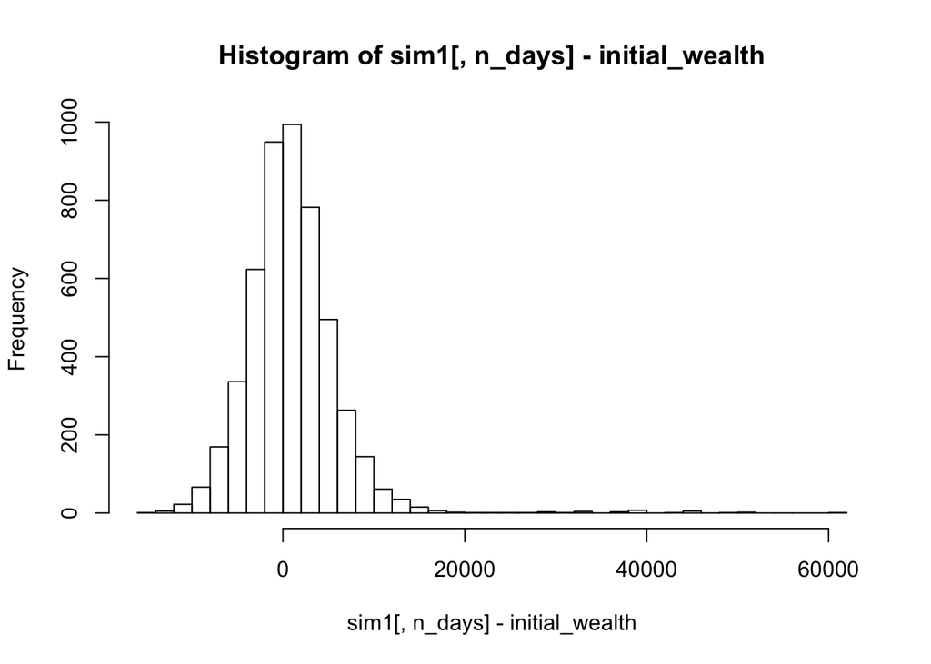

```r
hist(sim1[,n_days]- initial_wealth, breaks=30)
```

```r
quantile(sim1[,n_days], 0.05) - initial_wealth
```

```
##        5%
## -6072.107
```

```r
initial_wealth = 100000

sim1 = foreach(i=1:5000, .combine='rbind') %do% {
    total_wealth = initial_wealth
    weights = c(0.15, 0, 0, 0.75, 0.1)
    holdings = weights * total_wealth
    n_days = 20

    wealthtracker = rep(0, n_days)

    for(today in 1:n_days) {
        return.today = resample(all_returns, 1, orig.ids=FALSE)
        holdings = holdings + holdings*return.today
        total_wealth = sum(holdings)
        wealthtracker[today] = total_wealth
    }

    wealthtracker

}

mean(sim1[,n_days])
```

```
## [1] 101667.6
```

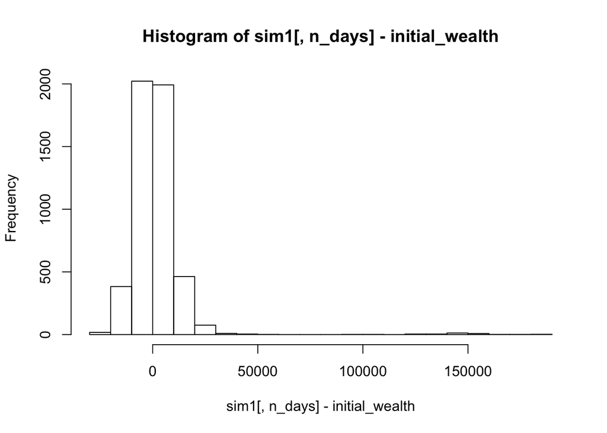

```r
hist(sim1[,n_days]- initial_wealth, breaks=30)
```

```r
quantile(sim1[,n_days], 0.05) - initial_wealth
```

```
##       5%
## -11747.4
```

```r
initial_wealth = 100000

sim1 = foreach(i=1:5000, .combine='rbind') %do% {

    total_wealth = initial_wealth
    weights = c(0.2, .8, 0, 0, 0)
    holdings = weights * total_wealth
    n_days = 20
    wealthtracker = rep(0, n_days)

    for(today in 1:n_days) {
        return.today = resample(all_returns, 1, orig.ids=FALSE)
        holdings = holdings + holdings*return.today
        total_wealth = sum(holdings)
        wealthtracker[today] = total_wealth
    }
    wealthtracker
}

mean(sim1[,n_days])
```

```
## [1] 100568.2
```

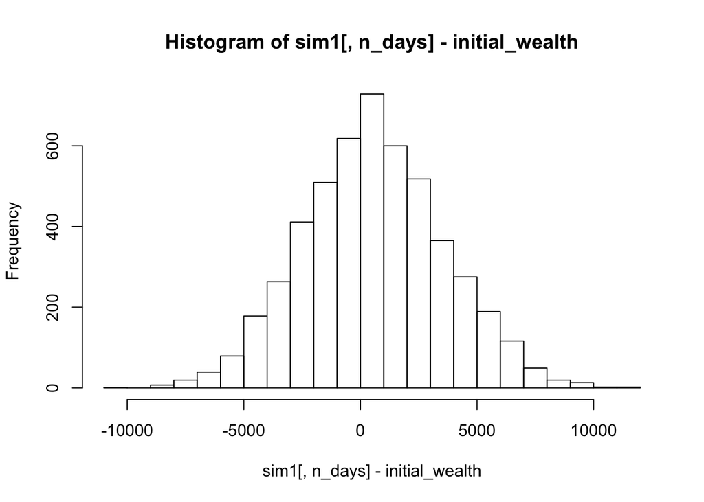

```r
hist(sim1[,n_days]- initial_wealth, breaks=30)
```

```r
quantile(sim1[,n_days], 0.05) - initial_wealth
```

```
##        5%
## -4312.717
```

```r
colMeans(all_returns) # Get the means down the columns of all_return
```

```
##    ClCl.SPYa    ClCl.TLTa    ClCl.LQDa    ClCl.EEMa    ClCl.VNQa
## 0.0003983176 0.0002737537 0.0002067942 0.0009971055 0.0004147192
```

```r
for (i in colnames(all_returns)){
  # This loop prints out all of the 5th quantiles for the 5 assets.
  print (i)
  print (quantile(all_returns[, i], .05))
}
```

```
## [1] "ClCl.SPYa"
##          5%
## -0.01888737
## [1] "ClCl.TLTa"
##          5%
## -0.01475381
## [1] "ClCl.LQDa"
##           5%
## -0.006346355
## [1] "ClCl.EEMa"
##          5%
## -0.02850711
## [1] "ClCl.VNQa"
##          5%
## -0.02805674
```